# Using a custom plot layout within `superb`

## The built-in plot layouts

When calling `superbPlot()`, you use the `plotStyle = "layout"` option to indicate which layout you wish to use. Internally, `superbPlot()` is calling a function whose name is `superbPlot."layout"()`. For example, with `plotStyle = "line"`, the plot is actually performed by the function `superbPlot.line()`.

- `superbPlot.line()` : shows the results as points and lines,
- `superbPlot.lineBand()`: Shows the confidence intervals as a semi-transparent band rather than with bars.
- `superbPlot.point()`: shows the results as points only,
- `superbPlot.bar()` : shows the results using bars,
- `superbPlot.pointjitter()`: shows the results with points, and the raw data with jittered points,
- `superbPlot.pointjitterviolin()`: also shows violin plot behind the jitter points, and
- `superbPlot.pointindividualline()`: show the results with fat points, and individual results with thin lines,
- `superbPlot.raincloud()`: Shows the results with distribution and jitter.

To determine if a certain function is `superbPlot`-compatible, use the following function:

```r
superb:::is.superbPlot.function("superbPlot.line")
```

```
## [1] TRUE
```

where you put between quote the name of a function. When devising your own, custom-made function, it is a good thing to check that it is `superbPlot`-compatible.

## Illustrating some of the built-in layouts

To get a sense of the currently available layouts, we first generate a dataset composed of randomly generated scores mimicking a 3 $\times$ 2 design with three degrees of Difficulties (as a between-group factor) and two days of testing (as a within-subject factor). It is believed (and simulated) that all two factors have main effets on the scores.

```r
testdata <- GRD(
    RenameDV   = "score",
    SubjectsPerGroup = 25,
    BSFactors  = "Difficulty(3)",
    WSFactors  = "Day(day1, day2)",
    Population = list(mean = 65,stddev = 12,rho = 0.5),
    Effects    = list("Day" = slope(-5), "Difficulty" = slope(3) )
)
head(testdata)
```

```
##   id Difficulty score.day1 score.day2
## 1  1          1   69.32737   64.58396
## 2  2          1   54.09485   53.13825
## 3  3          1   62.11526   36.56828
## 4  4          1   84.25968   57.77058
## 5  5          1   70.89638   50.41050
## 6  6          1   53.14770   47.44263
```

For simplicity, we define a function whose arguments are the dataset and the layout:

```r
mp <- function(data, style, ...) {
    superb(
        cbind(score.day1, score.day2) ~ Difficulty,
        data,
        WSFactors = "Day(2)",
        adjustments = list(purpose="difference", decorrelation="CA"),
        plotStyle = style,
        ...
    )+labs(title = paste("Layout is ''",style,"''",sep=""))
}
```

Lets compute the plots will the first six built-in layouts and show them

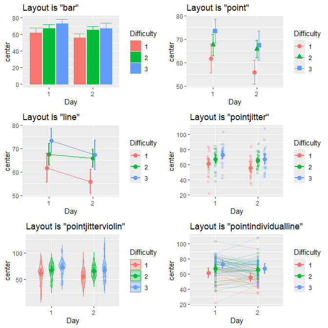

**Figure 1a**. Look of the six built-in layouts on the same random dataset

```r
p1 <- mp(testdata, "bar")
p2 <- mp(testdata, "point")
p3 <- mp(testdata, "line")
p4 <- mp(testdata, "pointjitter" )
p5 <- mp(testdata, "pointjitterviolin")
p6 <- mp(testdata, "pointindividualline")

library(gridExtra)
grid.arrange(p1,p2,p3,p4,p5,p6,ncol=2)
```

A cool format, a `raincloud` plot (Allen et al., 2021), is better seen with coordinates flipped over:

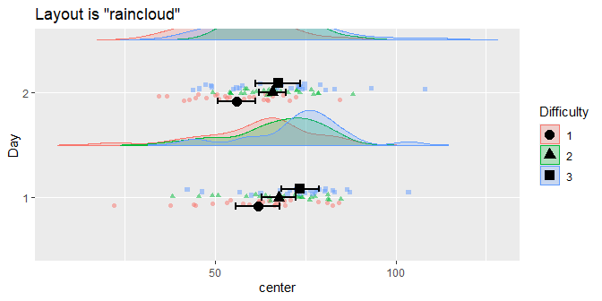

**Figure 1b**. The seventh layout, the raincloud

```r
mp(testdata, "raincloud") + coord_flip()
```

Finally, the following shows the latest layout, a box plot, better for showing median and confidence interval of the median, obtained with

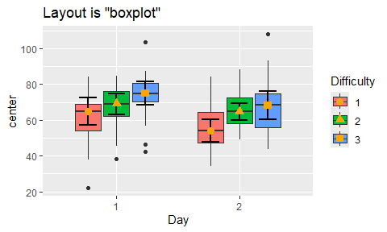

**Figure 1c**. Box plot of the data

```r
mp(testdata, "boxplot", statistic = "median", pointParams = list(color="orange"))
```

For more controls, you can manually set the colors, the fills and/or the shapes, as done here in a list:

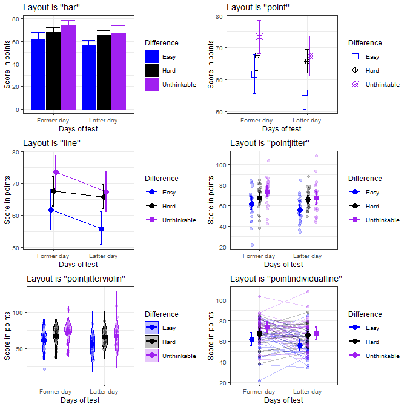

**Figure 2a**. The six built-in template with ornamental styling added.

```r
ornate = list(
    scale_colour_manual( name = "Difference",
        labels = c("Easy", "Hard", "Unthinkable"),
        values = c("blue", "black", "purple")) ,
    scale_fill_manual( name = "Difference",
        labels = c("Easy", "Hard", "Unthinkable"),
        values = c("blue", "black", "purple")) ,
    scale_shape_manual( name = "Difference",
        labels = c("Easy", "Hard", "Unthinkable") ,
        values = c(0, 10, 13)) ,
    theme_bw(base_size = 9) ,
    labs(x = "Days of test", y = "Score in points" ),
    scale_x_discrete(labels=c("1" = "Former day", "2" = "Latter day"))
)
library(gridExtra)
grid.arrange(
    p1+ornate, p2+ornate, p3+ornate,
    p4+ornate, p5+ornate, p6+ornate,
    ncol=2)
```

These are just a few examples. However, if these layouts do not fit yours needs, it is possible to devise a custom-made layout and inform `superbPlot` to use it. To that end, see the instructions below.

## Devising a custom-made plot layout

In a nutshell, the purpose of `superbPlot()` is to

- compile the summary information (location of the summary statistic, upper width and lower width of the interval) and that, for each level of the factors;
- applies all the adjustments needed in producing the summary;
- and finally, calls a plot function accepting pre-defined arguments

In devising your own plot function, it is important that (i) the function name begins with `superbPlot.`; (ii) the function accept very specific arguments with very precise names.

Here is the header for a function corresponding to a plot style called, say, *foo* (`plotStyle = "foo"`):

```r
superbPlot.foo <- function(
    summarydata,
    xfactor,
    groupingfactor,
    addfactors,
    rawdata
    # any optional argument you wish
) {
    plot <- ggplot() ## ggplot instructions...
    return(plot)
}
```

In what follow, it is assumed that one factor is placed on the horizontal axis (`xfactor`), another one is used to group the point (`groupingfactor`), and up to two additional factors will results in columns and rows of panels (`addfactors`; of course, in devising your own template, you may use different placement). `superbPlot()` is restricted to a maximum of four factors.

The arguments are:

- `summarydata`: this data frame will contain the column `center` indicating the statistic’s value, `lowerwidth` and `upperwidth` indicating how many units below and above `center` the error bar extends. The data frame will also have columns for all the factors, and there will be as many lines as there are combinations of factors.
- `xfactor` is the factor to put on the horizontal axis;
- `groupingfactor` is the factor used to create groups of points;
- `addfactors` are up to two additional factors to create the rows and columns of panels. `addfactors` is formatted for facetting (e.g., for factors “A” and “B”, `addfactors` would be “A~B”);
- `rawdata` : this data.frame contains the raw data with factors being transformed `as.factor` and the dependent column being renamed `DV`. When the data are in wide format, `rawdata` is reshaped to long format.
- `{optional arguments}` can be used. They must be named here; when calling `superbPlot()`, any argument whose name match your optional argument will be transmitted to your custom-made function.

## The simplest example

What follow is a simple example that will design a template that we will call `simple`. This layout will display the descriptive statistics and error bars. Everything will be black and white (no color instruction) and superimposed (no grouping instruction).

The result will be:

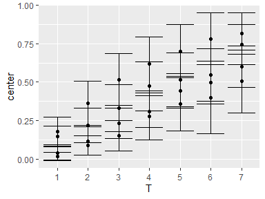

**Figure 3**. Mean score with 95% confidence interval using the `simple` plot layout.

To make this plot, we design a function `superbPlot.simple` as:

```r
superbPlot.simple <- function(
    summarydata, xfactor, groupingfactor, addfactors, rawdata
) {
    plot <- ggplot(
        data = summarydata,
        mapping = aes( x = !!sym(xfactor), y = center, group = !!sym(groupingfactor) )
    ) +
    geom_point(  ) +
    geom_errorbar( mapping = aes(ymin = center + lowerwidth,
                                 ymax = center + upperwidth)  )+
    facet_grid( addfactors )

    return(plot)
}
```

The first instruction, `ggplot` defines the source data to be `summarydata` with horizontal axis being in the string `xfactor` (the piece of instructions `!!sym( )` converts the string into a variable). The position of the descriptive statistics is automatically computed and stored in a column called `center`.

The second instruction put points for each `center`, and the third instruction places error bars. In that case, the `ymin` and `ymax` information are contained in `center+lowerwidth` and `center+upperwidth` where `lowerwidth` and `upperwidth` are automaticall computed and stored in the `summarydata` dataframe.

The last instructions generates distinct panels for each level of the remaining factors.

You can check that this function is `superbPlot`-compatible with:

```r
superb:::is.superbPlot.function("superbPlot.simple")
```

```
## [1] TRUE
```

If `TRUE`, then we are ready to use this layout, here with the demo dataset `TMB1964r` whose result was shown above in Figure 3:

```r
superb(
    crange(T1,T7) ~ Condition,
    TMB1964r,
    WSFactors = "T(7)",
    plotStyle = "simple"
)
```

## Optional arguments

The above `simple` layout does not accept optional arguments. To integrate optional arguments, one method is to insert graphic directives inside the layers, e.g., inside `geom_point`.

A convenient method is with `do.call` and `modifyList`, for example:

```r
do.call( geom_point, modifyList(
   list( size= 3 ##etc., the default directives##
   ), myownParams
))
```

A full example it therefore

```r
superbPlot.simpleWithOptions <- function(
    summarydata, xfactor, groupingfactor, addfactors, rawdata,
    myownpointParams = list(),  ## will be used to add the optional arguments to the function
    myownebParams    = list()  ## will be used to add the optional arguments to the function
) {
    plot <- ggplot(
        data = summarydata,
        mapping = aes( x = !!sym(xfactor), y = center, group=Condition)
    ) +
    do.call( geom_point, modifyList(
        list( color ="black" ),
        myownpointParams
    )) +
    do.call( geom_errorbar, modifyList(
        list( mapping = aes(ymin = center + lowerwidth,
                            ymax = center + upperwidth)  ),
        myownebParams
    )) +
    facet_grid( addfactors )

    return(plot)
}
superb:::is.superbPlot.function("superbPlot.simpleWithOptions")
```

```
## [1] TRUE
```

```r
superb(
    crange(T1,T7) ~ Condition,
    TMB1964r,
    WSFactors = "T(7)",
    plotStyle = "simpleWithOptions",
    ## here goes the optional arguments
    myownpointParams = list(size=1, color="purple", position = position_dodge(width = 0.3) ),
    myownebParams = list(linewidth=1, color="purple", position = position_dodge(width = 0.3) )
)
```

[output not shown]

## Getting feedback information

It is sometimes useful to extract variables out of the function when debugging the code. A useful function is to use `runDebug()`. This function (shipped with `suberb`) will display text and transfer any variables you want into the global environment.

```r
options(superb.feedback = 'all')
runDebug( 'where are we?', "Text to show when we get there",
  c("variable1", "variable2", "etc"),
  list( "var1InTheFct", "var2InTheFct", "varetcInTheFct")
)
```

```
## ==> Text to show when we get there <==
##     variables dumped in: variable1, variable2, etc
```

For example, the following will get the dataframes:

```r
superbPlot.empty <- function(
    summarydata, xfactor, groupingfactor, addfactors, rawdata
) {
    runDebug( 'inempty', "Dumping the two dataframes",
        c("summary","raw"), list(summarydata, rawdata))

    plot <- ggplot() # an empty plot
    return(plot)
}
options(superb.feedback = 'inempty')  ## turn on feedback when reaching 'inempty'
superb(
    crange(T1,T7) ~ Condition,
    TMB1964r,
    WSFactors = "T(7)",
    plotStyle = "empty"
)
```

```
## ==> Dumping the two dataframes <==
##     variables dumped in: summary, raw
```

You see `Dumping the two dataframes` followed by `summary` and `raw`. These two variables are now in the global environment and you can manipulate them. You can also use them in testing your plotting functions, for example

```r
superbPlot.simple(summary, "T", "Condition", ".~.", raw)
```

## An example

In what follow, we create a toy example where the raw data will be shown with smileys. Note that this example may not work in Rstudio (see “limitation” on emojifont [page](https://CRAN.R-project.org/package=emojifont) )

We first need the `emojifont` library

```r
# install.packages("emojifont")
library(emojifont)
```

Then we define a `"smiley"` layout where the emojis are shown with `geom_text` layer:

```r
superbPlot.smiley <- function( summarydata, xfactor, groupingfactor, addfactors, rawdata ) {
    # the early part bears on summary data with variable "center"
    plot <- ggplot(
        data    = summarydata,
        mapping = aes(
            x      = !!sym(xfactor),
            y      = center,
            fill   = !!sym(groupingfactor),
            shape  = !!sym(groupingfactor),
            colour = !!sym(groupingfactor) )
    ) +
    geom_point(position = position_dodge(width = .95)) +
    geom_errorbar( width = .6, position = position_dodge(.95),
              mapping = aes(ymin = center + lowerwidth, ymax = center + upperwidth)
    )+
    # this part bears on the rawdata only with variable "DV"
    geom_text(data = rawdata,
              position = position_jitter(0.5),
              family   = "EmojiOne",
              label    = emoji("smile"),
              size     = 6,
              mapping  = aes(x = !!sym(xfactor), y = DV, group = !!sym(groupingfactor) )
    ) +
    facet_grid( addfactors )

    return(plot)
}
```

We check that it is a `superbPlot`-compatible function:

```r
superb:::is.superbPlot.function("superbPlot.smiley")
```

```
## [1] TRUE
```

It is all we need! This layout can be inserted in a `superbPlot` call:

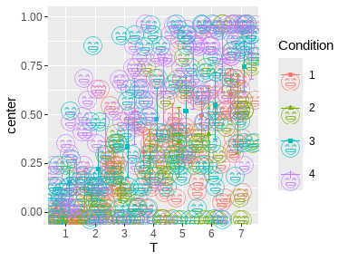

**Figure 5**. smile!

```r
superb(
    crange(T1,T7) ~ Condition,
    TMB1964r,
    WSFactors = "T(7)",
    plotStyle = "smiley"
)
```

# References

Allen, M., Poggiali, D., Whitaker, K., Marshall, T. R., Langen, J. van, & Kievit, R. A. (2021). Raincloud plots: A multi-platform tool for robust data visualization [version 2; peer review: 2 approved]. *Wellcome Open Reseach*, *4*, 1–15. https://doi.org/10.12688/wellcomeopenres.15191.2